# TRABAJOPERSONAL

Borja Gracia Loroño

24/1/2022

Ejercicio 1: Encuentra todos los vuelos que llegaron más de una hora tarde de lo previsto.

```r
library(nycflights13)
library(lubridate)
library(tidyverse)
lineas <- nycflights13::airlines
aeropuertos <- nycflights13::airports
vuelos <- nycflights13::flights
aviones <- nycflights13::planes
clima <- nycflights13::weather

retraso <- vuelos[which(vuelos$arr_delay > 60),]

dim(retraso)
```

```
## [1] 27789    19
```

```r
print("Hay 27789 vuelos que llegaron por lo menos 1h despues de su hora de llegada estimada")
```

```
## [1] "Hay 27789 vuelos que llegaron por lo menos 1h despues de su hora de llegada estimada"
```

Ejercicio 2: Encuentra todos los vuelos que volaron hacia San Francisco (aeropuertos SFO y OAK)

```r
vuelos_sf <- vuelos[vuelos$dest == "SFO" | vuelos$dest == "OAK",]
vuelos_sf
```

```
## # A tibble: 13,643 x 19
##     year month   day dep_time sched_dep_time dep_delay arr_time sched_arr_time
##    <int> <int> <int>    <int>          <int>     <dbl>    <int>          <int>
##  1  2013     1     1      558            600        -2      923            937
##  2  2013     1     1      611            600        11      945            931
##  3  2013     1     1      655            700        -5     1037           1045
##  4  2013     1     1      729            730        -1     1049           1115
##  5  2013     1     1      734            737        -3     1047           1113
##  6  2013     1     1      745            745         0     1135           1125
##  7  2013     1     1      746            746         0     1119           1129
##  8  2013     1     1      803            800         3     1132           1144
##  9  2013     1     1      826            817         9     1145           1158
## 10  2013     1     1     1029           1030        -1     1427           1355
## # ... with 13,633 more rows, and 11 more variables: arr_delay <dbl>,
## #   carrier <chr>, flight <int>, tailnum <chr>, origin <chr>, dest <chr>,
## #   air_time <dbl>, distance <dbl>, hour <dbl>, minute <dbl>, time_hour <dttm>
```

```r
dim(vuelos_sf)
```

```
## [1] 13643    19
```

```r
print("Hay 13643 vuelos que volaron hacia San Francisco")
```

```
## [1] "Hay 13643 vuelos que volaron hacia San Francisco"
```

Ejercicio 3: Encuentra todos los vuelos operados por United American (UA) o por American Airlines (AA)

```r
vuelos_op <- vuelos[vuelos$carrier == "UA" | vuelos$carrier == "AA",]
dim(vuelos_op)
```

```
## [1] 91394    19
```

```r
print("Encontramos 91.394 vuelos operados por United American y American Airlines")
```

```
## [1] "Encontramos 91.394 vuelos operados por United American y American Airlines"
```

Ejercicio 4: Encuentra todos los vuelos que salieron los meses de primavera (Abril, Mayo y Junio)

```r
vuelos_mes <- vuelos[vuelos$month == "4" | vuelos$month == "5" | vuelos$month == "6",]
dim(vuelos_mes)
```

```
## [1] 85369    19
```

```r
print("Aparecen 85.369 vuelos entre estos meses")
```

```
## [1] "Aparecen 85.369 vuelos entre estos meses"
```

Ejercicio 5: Encuentra todos los vuelos que llegaron más de una hora tarde pero salieron con menos de una hora de retraso.

```r
vuelos_hora <- vuelos[which(vuelos$arr_delay > 60 & vuelos$dep_delay < 60),]
dim(vuelos_hora)
```

```
## [1] 4956   19
```

```r
print("4956 vuelos llegaron mas de una hora tarde pero salieron con menos de una hora de retraso")
```

```
## [1] "4956 vuelos llegaron mas de una hora tarde pero salieron con menos de una hora de retraso"
```

Ejercicio 6: Encuentra todos los vuelos que salieron con más de una hora de retraso pero consiguieron llegar con menos de 30 minutos de retraso (el avión aceleró en el aire)

```r
vuelos_hora2 <- vuelos[which(vuelos$dep_delay > 60 & vuelos$arr_delay < 30),]
dim(vuelos_hora2)
```

```
## [1] 181  19
```

```r
print(" 181 vuelos salieron con más de una hora de retraso pero consiguieron
llegar con menos de 30 minutos de retraso")
```

```
## [1] " 181 vuelos salieron con más de una hora de retraso pero consiguieron\nllegar con menos de 30 minutos de retraso"
```

Ejercicio 7: Encuentra todos los vuelos que salen entre medianoche y las 7 de la mañana (vuelos nocturnos).

```r
vuelo_salida <- vuelos[which(vuelos$hour >=0 & vuelos$hour <=7),]
dim(vuelo_salida)
```

```
## [1] 50726    19
```

```r
print("salen entre medianoche y las 7 de la mañana (vuelos nocturnos")
```

```
## [1] "salen entre medianoche y las 7 de la mañana (vuelos nocturnos"
```

Ejercicio 8:¿Cuántos vuelos tienen un valor desconocido de dep_time?

```r
vuelo_desc <- vuelos[is.na(vuelos$dep_time),]
dim(vuelo_desc)
```

```
## [1] 8255   19
```

```r
print("Aparecen 8255 vuelos que tienen valores desconocidos de dep_time")
```

```
## [1] "Aparecen 8255 vuelos que tienen valores desconocidos de dep_time"
```

Ejercicio 9: ¿Qué variables del dataset contienen valores desconocidos?

```r
apply(X = is.na(vuelos), MARGIN = 2, FUN = sum)
```

```
##           year          month            day       dep_time sched_dep_time
##              0              0              0           8255              0
##      dep_delay       arr_time sched_arr_time      arr_delay        carrier
##           8255           8713              0           9430              0
##         flight        tailnum         origin           dest       air_time
##              0           2512              0              0           9430
##       distance           hour         minute      time_hour
##              0              0              0              0
```

Ejercicio 10: Ordena los vuelos de flights para encontrar los vuelos más retrasados en la salida. ¿Qué vuelos fueron los que salieron los primeros antes de lo previsto?

```r
arrange(vuelos, desc(dep_delay))
```

```
## # A tibble: 336,776 x 19
##     year month   day dep_time sched_dep_time dep_delay arr_time sched_arr_time
##    <int> <int> <int>    <int>          <int>     <dbl>    <int>          <int>
##  1  2013     1     9      641            900      1301     1242           1530
##  2  2013     6    15     1432           1935      1137     1607           2120
##  3  2013     1    10     1121           1635      1126     1239           1810
##  4  2013     9    20     1139           1845      1014     1457           2210
##  5  2013     7    22      845           1600      1005     1044           1815
##  6  2013     4    10     1100           1900       960     1342           2211
##  7  2013     3    17     2321            810       911      135           1020
##  8  2013     6    27      959           1900       899     1236           2226
##  9  2013     7    22     2257            759       898      121           1026
## 10  2013    12     5      756           1700       896     1058           2020
## # ... with 336,766 more rows, and 11 more variables: arr_delay <dbl>,
## #   carrier <chr>, flight <int>, tailnum <chr>, origin <chr>, dest <chr>,
## #   air_time <dbl>, distance <dbl>, hour <dbl>, minute <dbl>, time_hour <dttm>
```

```r
print("Encontramos los vuelos más retrasados en la salida")
```

```
## [1] "Encontramos los vuelos más retrasados en la salida"
```

```r
arrange(vuelos, dep_delay)
```

```
## # A tibble: 336,776 x 19
##     year month   day dep_time sched_dep_time dep_delay arr_time sched_arr_time
##    <int> <int> <int>    <int>          <int>     <dbl>    <int>          <int>
##  1  2013    12     7     2040           2123       -43       40           2352
##  2  2013     2     3     2022           2055       -33     2240           2338
##  3  2013    11    10     1408           1440       -32     1549           1559
##  4  2013     1    11     1900           1930       -30     2233           2243
##  5  2013     1    29     1703           1730       -27     1947           1957
##  6  2013     8     9      729            755       -26     1002            955
##  7  2013    10    23     1907           1932       -25     2143           2143
##  8  2013     3    30     2030           2055       -25     2213           2250
##  9  2013     3     2     1431           1455       -24     1601           1631
## 10  2013     5     5      934            958       -24     1225           1309
## # ... with 336,766 more rows, and 11 more variables: arr_delay <dbl>,
## #   carrier <chr>, flight <int>, tailnum <chr>, origin <chr>, dest <chr>,
## #   air_time <dbl>, distance <dbl>, hour <dbl>, minute <dbl>, time_hour <dttm>
```

```r
print("En este caso nos da una idea de aquellos vuelos que salieron los primeros")
```

```
## [1] "En este caso nos da una idea de aquellos vuelos que salieron los primeros"
```

Ejercicio 11: Ordena los vuelos de flights para encontrar los vuelos más rápidos. Usa el concepto de rapidez que consideres.

```r
head(arrange(flights, air_time))
```

```
## # A tibble: 6 x 19
##    year month   day dep_time sched_dep_time dep_delay arr_time sched_arr_time
##   <int> <int> <int>    <int>          <int>     <dbl>    <int>          <int>
## 1  2013     1    16     1355           1315        40     1442           1411
## 2  2013     4    13      537            527        10      622            628
## 3  2013    12     6      922            851        31     1021            954
## 4  2013     2     3     2153           2129        24     2247           2224
## 5  2013     2     5     1303           1315       -12     1342           1411
## 6  2013     2    12     2123           2130        -7     2211           2225
## # ... with 11 more variables: arr_delay <dbl>, carrier <chr>, flight <int>,
## #   tailnum <chr>, origin <chr>, dest <chr>, air_time <dbl>, distance <dbl>,
## #   hour <dbl>, minute <dbl>, time_hour <dttm>
```

```r
print("Consideramos los vuelos más rápidos como aquellos que están menos tiempo en el aire, por lo tanto, mediante la función anterior encontramos aquellos vuelos que fueron más rapidos. En este caso serían los dos primeros en la tabla.")
```

```
## [1] "Consideramos los vuelos más rápidos como aquellos que están menos tiempo en el aire, por lo tanto, mediante la función anterior encontramos aquellos vuelos que fueron más rapidos. En este caso serían los dos primeros en la tabla."
```

Ejercicio 12: ¿Qué vuelos tienen los trayectos más largos?

```r
arrange(vuelos, desc(distance))
```

```
## # A tibble: 336,776 x 19
##     year month   day dep_time sched_dep_time dep_delay arr_time sched_arr_time
##    <int> <int> <int>    <int>          <int>     <dbl>    <int>          <int>
##  1  2013     1     1      857            900        -3     1516           1530
##  2  2013     1     2      909            900         9     1525           1530
##  3  2013     1     3      914            900        14     1504           1530
##  4  2013     1     4      900            900         0     1516           1530
##  5  2013     1     5      858            900        -2     1519           1530
##  6  2013     1     6     1019            900        79     1558           1530
##  7  2013     1     7     1042            900       102     1620           1530
##  8  2013     1     8      901            900         1     1504           1530
##  9  2013     1     9      641            900      1301     1242           1530
## 10  2013     1    10      859            900        -1     1449           1530
## # ... with 336,766 more rows, and 11 more variables: arr_delay <dbl>,
## #   carrier <chr>, flight <int>, tailnum <chr>, origin <chr>, dest <chr>,
## #   air_time <dbl>, distance <dbl>, hour <dbl>, minute <dbl>, time_hour <dttm>
```

```r
print("Consideramos la distancia para averiguar los trayectos más largos, de esta manera ordenamos los vuelos atendiendo a sus distancias de mayor a menor, en orden descendente")
```

```
## [1] "Consideramos la distancia para averiguar los trayectos más largos, de esta manera ordenamos los vuelos atendiendo a sus distancias de mayor a menor, en orden descendente"
```

Ejercicio 13:¿Qué vuelos tienen los trayectos más cortos?

```r
arrange(vuelos, distance)
```

```
## # A tibble: 336,776 x 19
##     year month   day dep_time sched_dep_time dep_delay arr_time sched_arr_time
##    <int> <int> <int>    <int>          <int>     <dbl>    <int>          <int>
##  1  2013     7    27       NA            106        NA       NA            245
##  2  2013     1     3     2127           2129        -2     2222           2224
##  3  2013     1     4     1240           1200        40     1333           1306
##  4  2013     1     4     1829           1615       134     1937           1721
##  5  2013     1     4     2128           2129        -1     2218           2224
##  6  2013     1     5     1155           1200        -5     1241           1306
##  7  2013     1     6     2125           2129        -4     2224           2224
##  8  2013     1     7     2124           2129        -5     2212           2224
##  9  2013     1     8     2127           2130        -3     2304           2225
## 10  2013     1     9     2126           2129        -3     2217           2224
## # ... with 336,766 more rows, and 11 more variables: arr_delay <dbl>,
## #   carrier <chr>, flight <int>, tailnum <chr>, origin <chr>, dest <chr>,
## #   air_time <dbl>, distance <dbl>, hour <dbl>, minute <dbl>, time_hour <dttm>
```

```r
print("Y de esta manera aquellos que tienen los trayectos más cortos, es decir, los que tienen las distancias más cortas, los ordenamos de manera ascendente")
```

```
## [1] "Y de esta manera aquellos que tienen los trayectos más cortos, es decir, los que tienen las distancias más cortas, los ordenamos de manera ascendente"
```

Ejercicio 14: El dataset de vuelos tiene dos variables, dep_time y sched_dep_time muy útiles pero difíciles de usar por cómo vienen dadas al no ser variables continuas. Fíjate que cuando pone 559, se refiere a que el vuelo salió a las 5:59… Convierte este dato en otro más útil que represente el número de minutos que pasan desde media noche.

```r
dep_time_min <- (vuelos$dep_time %/% 100 * 60) + (vuelos$dep_time %% 100)
sched_dep_ti_min <- (vuelos$sched_dep_time %/% 100 * 60) + (vuelos$sched_dep_time %% 100)
```

Ejercicio 15: Compara los valores de dep_time, sched_dep_time y dep_delay. ¿Cómo deberían relacionarse estos tres números? Compruébalo y haz las correcciones numéricas que necesitas.

```r
dep_delay_difference <- vuelos$dep_delay - dep_time_min + sched_dep_ti_min
dep_delay_difference
```

[output not shown]

[output cut: 7129 more lines]

```r
flights_times <- mutate(flights, dep_time_min, sched_dep_ti_min, dep_delay_difference)
flights_times
```

```
## # A tibble: 336,776 x 22
##     year month   day dep_time sched_dep_time dep_delay arr_time sched_arr_time
##    <int> <int> <int>    <int>          <int>     <dbl>    <int>          <int>
##  1  2013     1     1      517            515         2      830            819
##  2  2013     1     1      533            529         4      850            830
##  3  2013     1     1      542            540         2      923            850
##  4  2013     1     1      544            545        -1     1004           1022
##  5  2013     1     1      554            600        -6      812            837
##  6  2013     1     1      554            558        -4      740            728
##  7  2013     1     1      555            600        -5      913            854
##  8  2013     1     1      557            600        -3      709            723
##  9  2013     1     1      557            600        -3      838            846
## 10  2013     1     1      558            600        -2      753            745
## # ... with 336,766 more rows, and 14 more variables: arr_delay <dbl>,
## #   carrier <chr>, flight <int>, tailnum <chr>, origin <chr>, dest <chr>,
## #   air_time <dbl>, distance <dbl>, hour <dbl>, minute <dbl>, time_hour <dttm>,
## #   dep_time_min <dbl>, sched_dep_ti_min <dbl>, dep_delay_difference <dbl>
```

```r
print("Estas tres variables están relacionadas entre sí. Observamos como la hora de salida real es igual a la hora de salida estimada mas el retraso que se produce en la salida del avión.Las discrepancias podrían deberse a que un vuelo estaba programado para salir antes de medianoche, pero se retrasó después de medianoche. Todas estas discrepancias son exactamente iguales a 1440 (24 horas), y los vuelos con estas discrepancias estaban programados para salir más tarde en el día.")
```

[output not shown]

Ejercicio 16: Investiga si existe algún patrón del número de vuelos que se cancelan cada día.

```r
vueloscancelados <-  vuelos %>%
  mutate(cancelado = (is.na(arr_delay) | is.na(arr_delay))) %>%
  group_by(year, month, day) %>%
  summarise(num_cancelado = sum(cancelado), num_vuelo = n(),)
```

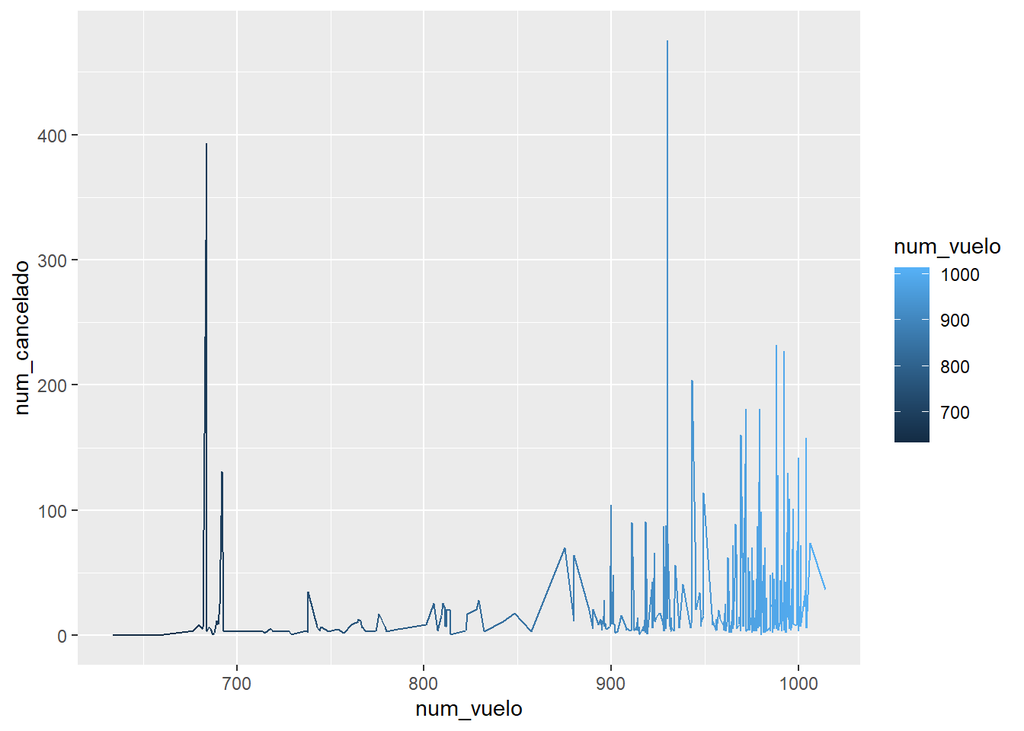

```r
ggplot(vueloscancelados) +
  geom_line(aes(x = num_vuelo, y = num_cancelado, col=num_vuelo,))
```

```r
print("Observamos en la gráfico que el número de vuelos cancelados aumenta con el número total de vuelos")
```

```
## [1] "Observamos en la gráfico que el número de vuelos cancelados aumenta con el número total de vuelos"
```

Ejercicio 17: Investiga si la proporción de vuelos cancelados está relacionada con el retraso promedio por día en los vuelos.

```r
proptardanz_cancel <-
  vuelos %>%
  mutate(cancelados = (is.na(tailnum))) %>%
  group_by(year, month, day) %>%
  summarise(prop_cancelados = mean(cancelados),med_dep_delay = mean(dep_delay, na.rm = TRUE),med_arr_delay = mean(arr_delay, na.rm = TRUE)) %>% ungroup()
proptardanz_cancel
```

```
## # A tibble: 365 x 6
##     year month   day prop_cancelados med_dep_delay med_arr_delay
##    <int> <int> <int>           <dbl>         <dbl>         <dbl>
##  1  2013     1     1         0               11.5         12.7
##  2  2013     1     2         0.00212         13.9         12.7
##  3  2013     1     3         0.00219         11.0          5.73
##  4  2013     1     4         0.00219          8.95        -1.93
##  5  2013     1     5         0.00139          5.73        -1.53
##  6  2013     1     6         0                7.15         4.24
##  7  2013     1     7         0.00107          5.42        -4.95
##  8  2013     1     8         0.00111          2.55        -3.23
##  9  2013     1     9         0.00222          2.28        -0.264
## 10  2013     1    10         0.00215          2.84        -5.90
## # ... with 355 more rows
```

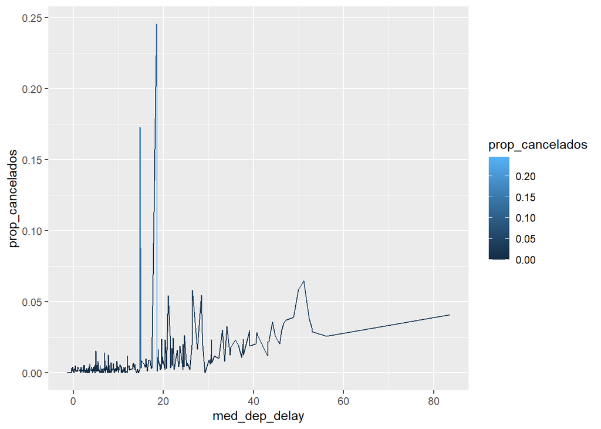

```r
ggplot(proptardanz_cancel) +
  geom_line(aes(x = med_dep_delay, y = prop_cancelados, col=prop_cancelados))
```

```r
print("Exiate una relación entre los vuelos cancelados y el retraso promedio por día en estos")
```

```
## [1] "Exiate una relación entre los vuelos cancelados y el retraso promedio por día en estos"
```

Ejercicio 18: Investiga si la proporción de vuelos cancelados está relacionada con el retraso promedio por aeropuerto en los vuelos.

```r
proptard_canc_aeropuerto <-
  vuelos %>%
  mutate(cancelados = (is.na(tailnum))) %>%
  group_by(origin, dest) %>%
  summarise(prop_cancelados = mean(cancelados),med_dep_delay = mean(dep_delay, na.rm = TRUE),med_arr_delay = mean(arr_delay, na.rm = TRUE)) %>% ungroup()
```

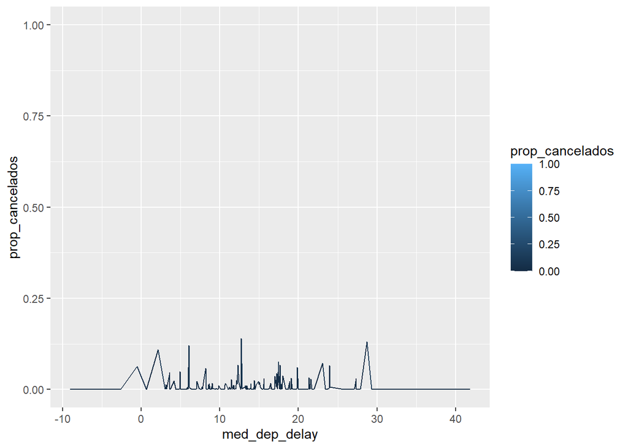

```r
ggplot(proptard_canc_aeropuerto) +
  geom_line(aes(x = med_dep_delay, y = prop_cancelados, col= prop_cancelados))
```

```r
print("No aparece una relación significativa entre la proporción de vuelos cancelados con el retraso promedio por aeropuerto en los vuelos")
```

```
## [1] "No aparece una relación significativa entre la proporción de vuelos cancelados con el retraso promedio por aeropuerto en los vuelos"
```

Ejercicio 19: ¿Qué compañía aérea sufre los peores retrasos?

```r
vuelos %>%
   group_by(carrier) %>%
   summarise(arr_delay = mean(arr_delay, na.rm = TRUE)) %>%
   arrange(desc(arr_delay))
```

```
## # A tibble: 16 x 2
##    carrier arr_delay
##    <chr>       <dbl>
##  1 F9         21.9
##  2 FL         20.1
##  3 EV         15.8
##  4 YV         15.6
##  5 OO         11.9
##  6 MQ         10.8
##  7 WN          9.65
##  8 B6          9.46
##  9 9E          7.38
## 10 UA          3.56
## 11 US          2.13
## 12 VX          1.76
## 13 DL          1.64
## 14 AA          0.364
## 15 HA         -6.92
## 16 AS         -9.93
```

```r
print("La compañia F9 es aquella que sufre los peores retrasos como nos indica la tabla. En este caso se refiere a los retrasos de llegada")
```

```
## [1] "La compañia F9 es aquella que sufre los peores retrasos como nos indica la tabla. En este caso se refiere a los retrasos de llegada"
```

```r
vuelos %>%
   group_by(carrier) %>%
   summarise(dep_delay = mean(dep_delay, na.rm = TRUE)) %>%
   arrange(desc(dep_delay))
```

```
## # A tibble: 16 x 2
##    carrier dep_delay
##    <chr>       <dbl>
##  1 F9          20.2
##  2 EV          20.0
##  3 YV          19.0
##  4 FL          18.7
##  5 WN          17.7
##  6 9E          16.7
##  7 B6          13.0
##  8 VX          12.9
##  9 OO          12.6
## 10 UA          12.1
## 11 MQ          10.6
## 12 DL           9.26
## 13 AA           8.59
## 14 AS           5.80
## 15 HA           4.90
## 16 US           3.78
```

```r
print("Y en este caso se refiere a los retrasos de salida de los aviones")
```

```
## [1] "Y en este caso se refiere a los retrasos de salida de los aviones"
```

Ejercicio 20: Queremos saber qué hora del día nos conviene volar si queremos evitar los retrasos en la salida.

```r
vuelos %>%
  group_by(hour) %>%
  summarise(dep_delay = mean(dep_delay, na.rm = TRUE)) %>%
  arrange(dep_delay)
```

```
## # A tibble: 20 x 2
##     hour dep_delay
##    <dbl>     <dbl>
##  1     5     0.688
##  2     6     1.64
##  3     7     1.91
##  4     8     4.13
##  5     9     4.58
##  6    10     6.50
##  7    11     7.19
##  8    12     8.61
##  9    13    11.4
## 10    14    13.8
## 11    23    14.0
## 12    15    16.9
## 13    16    18.8
## 14    22    18.8
## 15    17    21.1
## 16    18    21.1
## 17    21    24.2
## 18    20    24.3
## 19    19    24.8
## 20     1   NaN
```